# Creative Assignment 2

## Adding Alternative Coordinate Reference Systems

```r
SA_Brazil <- "+proj=poly +lat_0=0 +lon_0=-54 +x_0=0 +y_0=0 +ellps=aust_SA +units=m +no_defs"
SA_ICN <- "+proj=lcc +lat_1=9 +lat_2=3 +lat_0=6 +lon_0=-66 +x_0=1000000 +y_0=1000000 +ellps=intl +units=m +no_defs "
SA_MX <- "+proj=aea +lat_1=14.5 +lat_2=32.5 +lat_0=24 +lon_0=-105 +x_0=0 +y_0=0 +ellps=GRS80 +datum=NAD83 +units=m +no_defs"
```

### Projection 1 - Brazil Polyconic Zeroed False Northing and Easting

For this map, the coordinate reference system was changed to the Brazil Polyconic Zeroed False Northing and Easting projection.

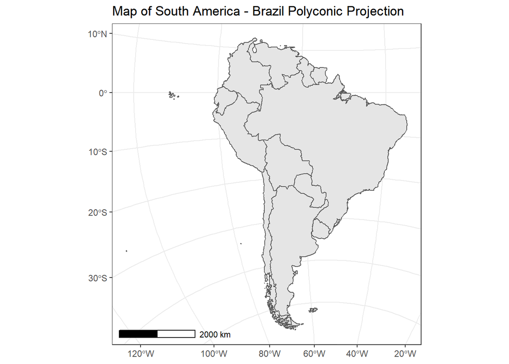

```r
ggplot(SA_countries) +
  geom_sf() +
  coord_sf(crs = SA_Brazil) +
  ggtitle("Map of South America - Brazil Polyconic Projection") +
  annotation_scale() +
  theme_bw()
```

### Projection 2 - Mexico Albers Equal Area Conic

For this map, the coordinate reference system was changed to the Mexico Albers Equal Area Conic projection.

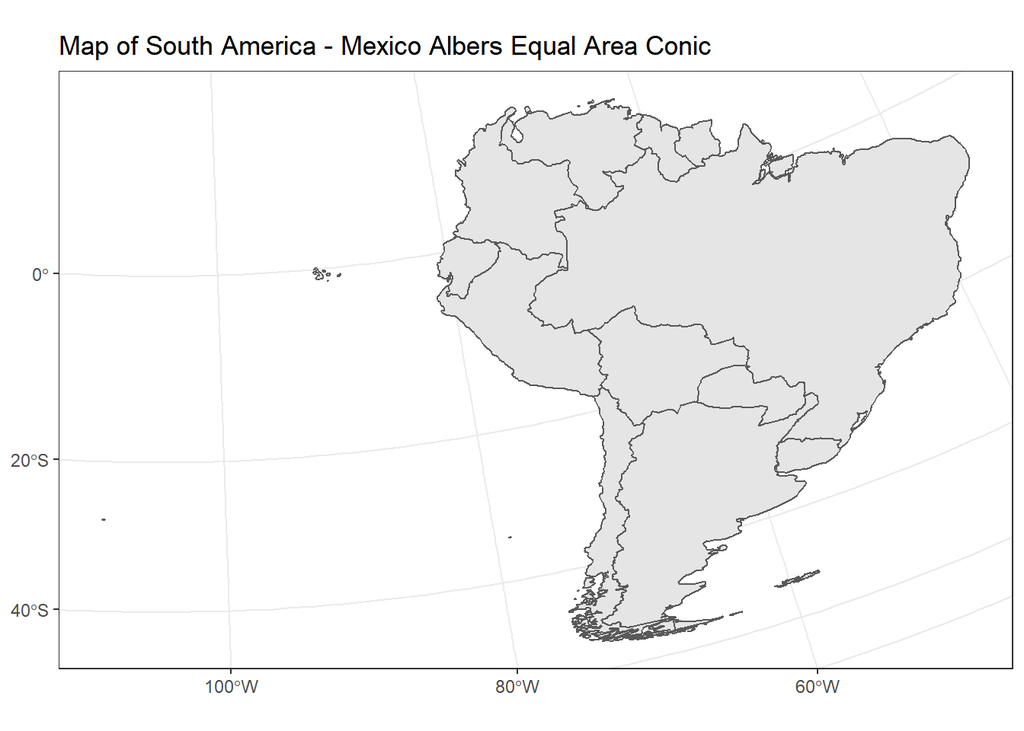

```r
ggplot(SA_countries) +
  geom_sf() +
  coord_sf(crs = SA_MX) +
  ggtitle("Map of South America - Mexico Albers Equal Area Conic") +
  theme_bw()
```

### Projection 3 - ICN Regional

For this map, the coordinate reference system was changed to the ICN Regional projection.

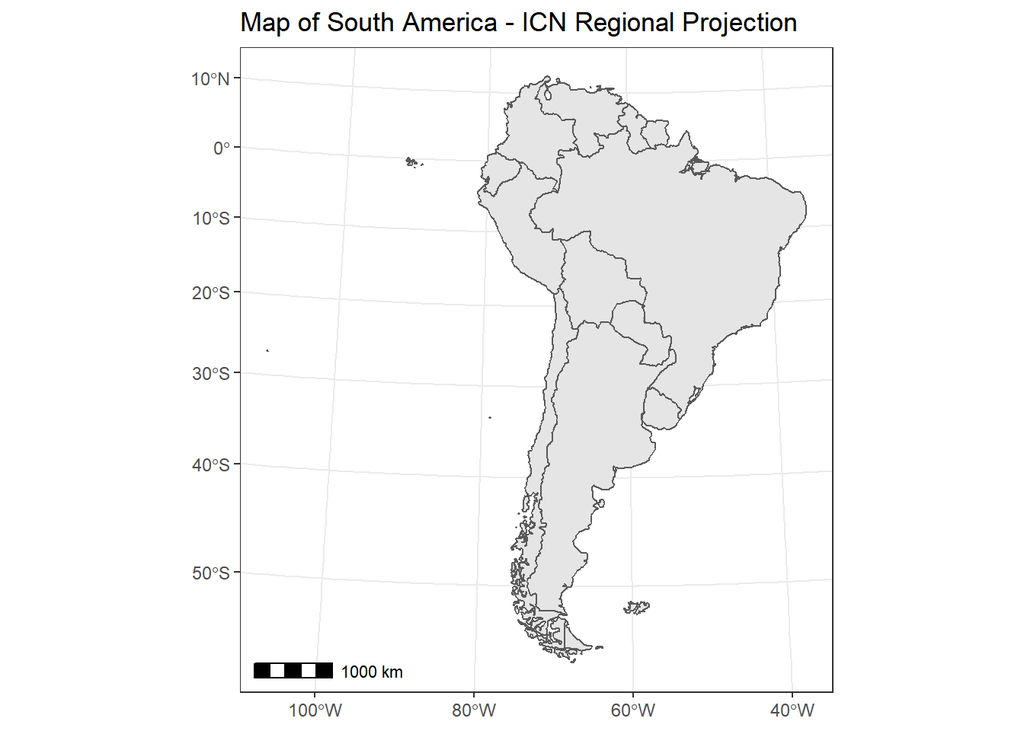

```r
ggplot(SA_countries) +
  geom_sf() +
  coord_sf(crs = SA_ICN) +
  ggtitle("Map of South America - ICN Regional Projection") +
  annotation_scale() +
  theme_bw()
```

## Mapping Variables

I decided to use the map of South America with the Brazil Polyconic Projection in the next section of the assignment to map a variable spatially.

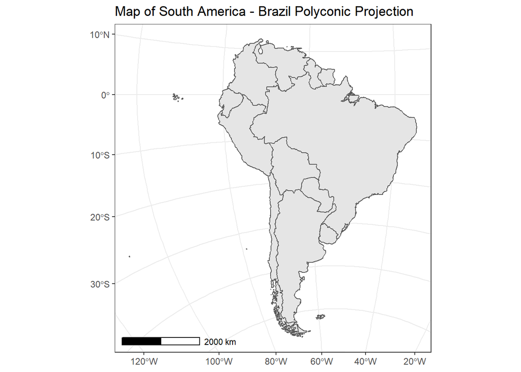

```r
sa_transformed <- SA_countries %>%
  st_transform(crs = SA_Brazil)

ggplot(sa_transformed) +
  geom_sf() +
  ggtitle("Map of South America - Brazil Polyconic Projection") +
  annotation_scale() +
  theme_bw()
```

### Downloading COVID-19 Data

I downloaded country level COVID-19 data from John Hopkins University’s Center for Systems Science and Engineering - https://github.com/CSSEGISandData/COVID-19/tree/master/csse_covid_19_data/csse_covid_19_daily_reports

```r
covid_SA<- read_csv("https://raw.githubusercontent.com/CSSEGISandData/COVID-19/master/csse_covid_19_data/csse_covid_19_daily_reports/09-19-2020.csv")

sum_covid <- covid_SA %>% group_by(Country_Region) %>% summarize(newDeath = sum(Deaths))
```

### Chloropleth Map of COVID 19 Deaths in South America as of September 19 2020

Here I create a Chloropleth map. The code is based on code from the online tutorial by Carole. Alex also provided support on code to create labels and combine data on death for each country (thank you!). One challenge I had was preventing the overlapping of the country labels. I found a package called ggrepel that prevents label overlap within geom_text but does not seem to work with geom_sf_text.

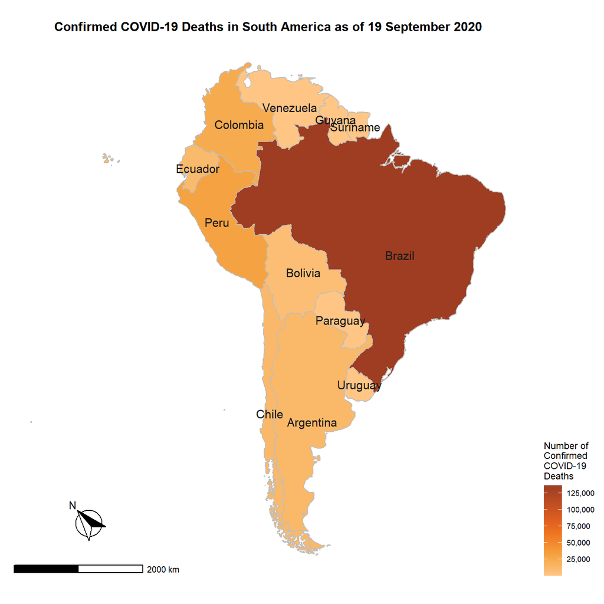

```r
covid_countries <-sa_transformed %>%
  left_join(sum_covid, by = c("name" = "Country_Region"))

covid_countries3 <- covid_countries[-c(7),]


ggplot(covid_countries3, aes(fill = newDeath, label = "Country_Region")) +
  geom_sf(color = "gray") +
  scale_fill_continuous_tableau(palette = "Orange",
    name = "Number of\nConfirmed\nCOVID-19\nDeaths",
    breaks = seq(0, 150000, by = 25000),
    labels = formatC(seq(0, 150000, by = 25000),
                     big.mark = ",", format = "f", digits = 0)) +
  theme_map() +
   ggtitle("Confirmed COVID-19 Deaths in South America as of 19 September 2020") +
  theme(legend.position = "right",
        legend.direction="vertical") +
  geom_sf_text(aes(label = name), size=4, color = "gray10", inherit.aes = FALSE) +
  annotation_scale() +
  annotation_north_arrow(location = "bl", which_north = "true",
        pad_x = unit(0.75, "in"), pad_y = unit(0.5, "in"),
        style = north_arrow_fancy_orienteering) +
  theme(plot.title = element_text(face="bold", size=12, hjust = 0.5))
```

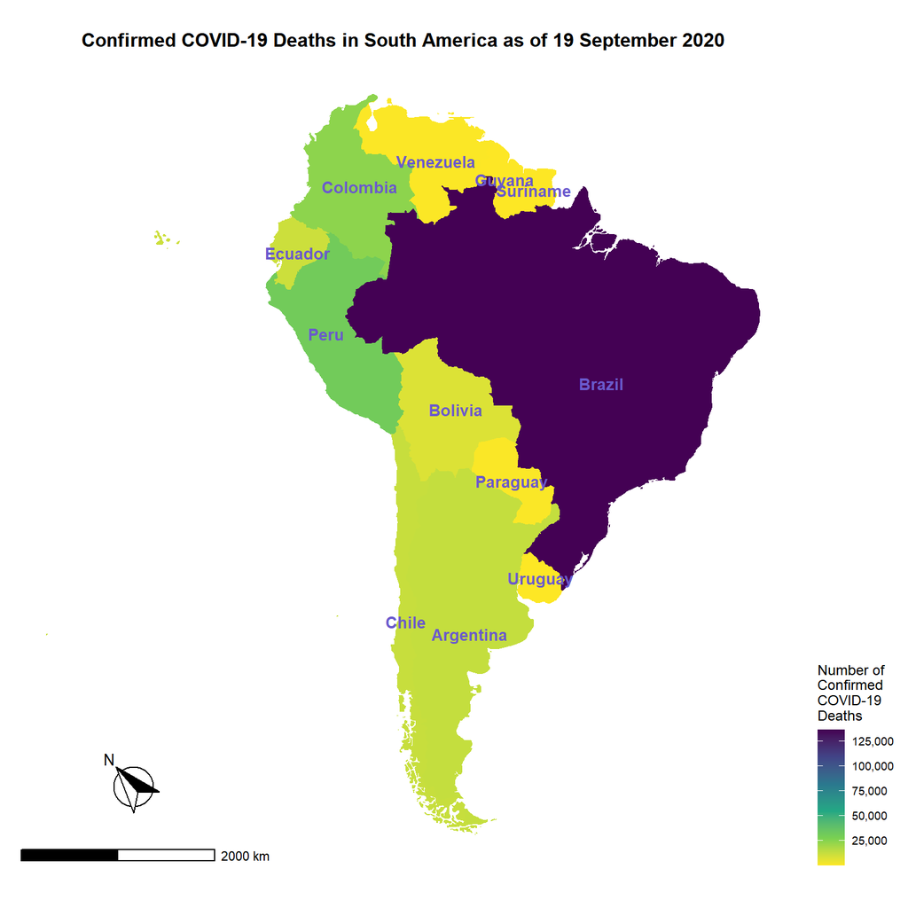

```r
covid_countries3 <-sa_transformed %>%
  left_join(sum_covid, by = c("name" = "Country_Region"))

covid_countries3 <- covid_countries[-c(7),]

ggplot(covid_countries3, aes(fill = newDeath, label = "Country_Region")) +
  geom_sf(color = NA) +
  scale_fill_viridis_c(option = "viridis", direction = -1,
    name = "Number of\nConfirmed\nCOVID-19\nDeaths",
    breaks = seq(0, 150000, by = 25000),
    labels = formatC(seq(0, 150000, by = 25000),
                     big.mark = ",", format = "f", digits = 0)) +
  theme_map() +
  ggtitle("Confirmed COVID-19 Deaths in South America as of 19 September 2020") +
  theme(legend.position = "right",
        legend.direction="vertical") +
   geom_sf_text(aes(label = name), size=3.5, color = "slateblue", fontface = "bold", inherit.aes = FALSE) +
  annotation_scale() +
  annotation_north_arrow(location = "bl", which_north = "true",
        pad_x = unit(0.75, "in"), pad_y = unit(0.5, "in"),
        style = north_arrow_fancy_orienteering) +
  theme(plot.title = element_text(face="bold", size=12, hjust = 0.5))
```

### Proportional Symbol Map of COVID 19 Deaths in South America as of September 19 2020

Here I create a proportional symbol map. The code is based on code from the online tutorial by Carole (thank you!).

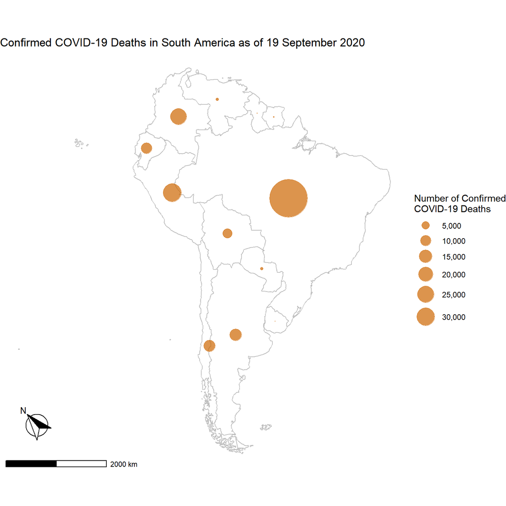

```r
covid_circles <- covid_countries %>%
  st_centroid()

ggplot(covid_countries) +
  geom_sf(fill = NA, color = "gray") +
  geom_sf(data = covid_circles,
          aes(size = newDeath),
          alpha = 0.7, color = "darkorange3") +
    scale_size_continuous(name = "Number of Confirmed\nCOVID-19 Deaths",
    breaks = seq(0, 30000, by = 5000),
    labels = formatC(seq(0, 30000, by = 5000),
                     big.mark = ",", format = "f", digits = 0),
    range = c(0, 20)) +
  ggtitle("Confirmed COVID-19 Deaths in South America as of 19 September 2020") +
  annotation_scale() +
  annotation_north_arrow(location = "bl", which_north = "true",
        pad_x = unit(0.25, "in"), pad_y = unit(0.5, "in"),
        style = north_arrow_fancy_orienteering) +
  theme(plot.title = element_text(face="bold", size=12, hjust = 0.5)) +
  theme_void()
```

### Dorling Cartogram of COVID 19 Deaths in South America as of September 19 2020

Here I created a dorling cartogram. The code is based on the code from the online tutorial by Carole. Alex also provided support on code for addressing all countries with deaths labeled N/A (in this case, the Falkland Islands). Thank you both!

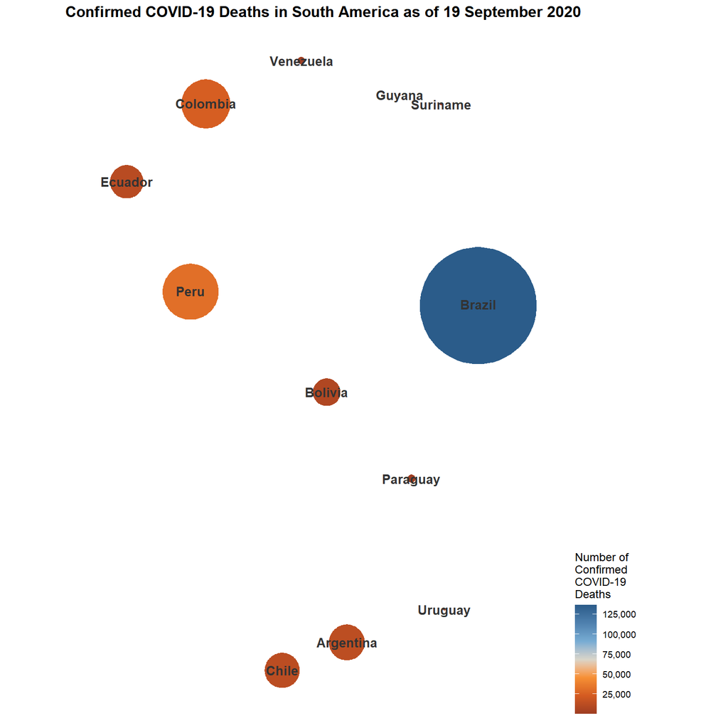

```r
covid_countries3[is.na(covid_countries3)] <- 0

covid_countries3 <- covid_countries[-c(7),]

covid_dorling <- covid_countries3 %>%
 cartogram_dorling("newDeath")

ggplot(covid_dorling, aes(fill = newDeath)) +
 geom_sf(color = NA) +
 scale_fill_gradient2_tableau(
    name = "Number of\nConfirmed\nCOVID-19\nDeaths",
    breaks = seq(0, 150000, by = 25000),
    labels = formatC(seq(0, 150000, by = 25000),
                     big.mark = ",", format = "f", digits = 0)) +
  ggtitle("Confirmed COVID-19 Deaths in South America as of 19 September 2020") +
  theme(plot.title = element_text(face="bold", hjust = 0.5))+
  geom_sf_label(aes(geometry, label = name), size = 3.5, color = "gray20", fill = NA, fontface = "bold", label.size =   NA) +
  theme_map() +
  theme(legend.background = element_blank()) +
  theme(plot.title = element_text(face="bold", size=12, hjust = 0.5)) +
  theme(legend.position = "right",
        legend.direction="vertical")
```

### Modified Area Map of COVID 19 Deaths in South America as of September 19 2020

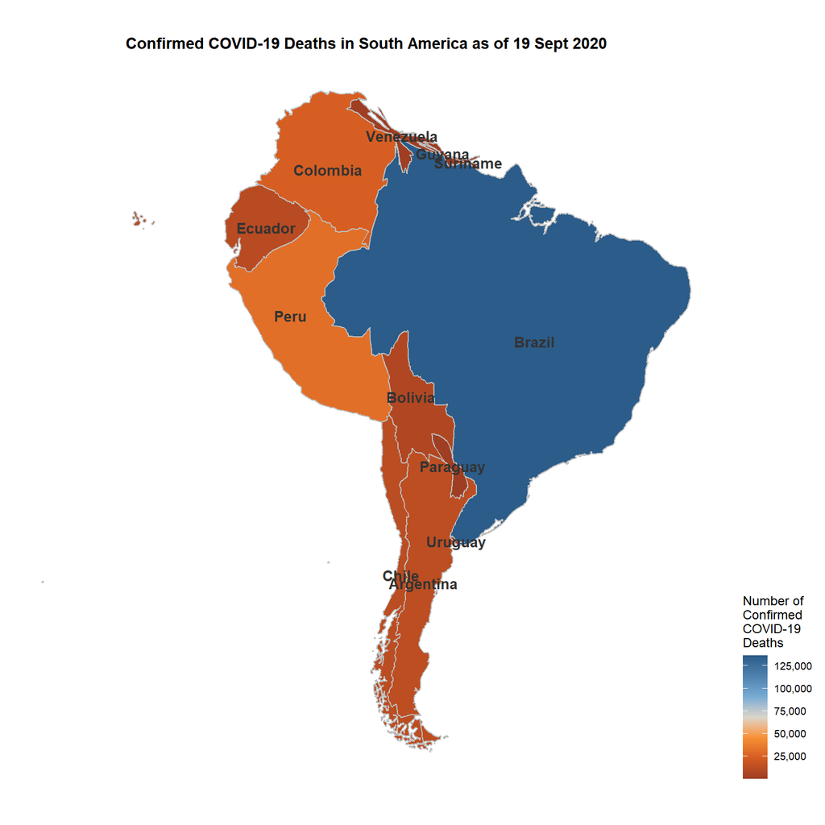

```r
covid_countries3 <- covid_countries[-c(7),]

covid_cart_cont <- covid_countries3 %>%
  cartogram_cont("newDeath")

ggplot(covid_cart_cont, aes(fill = newDeath)) +
 geom_sf(color = "gray") +
 scale_fill_gradient2_tableau(
    name = "Number of\nConfirmed\nCOVID-19\nDeaths",
    breaks = seq(0, 150000, by = 25000),
    labels = formatC(seq(0, 150000, by = 25000),
                     big.mark = ",", format = "f", digits = 0)) +
  ggtitle("Confirmed COVID-19 Deaths in South America as of 19 Sept 2020") +
  geom_sf_label(aes(geometry, label = name), size = 3.5, color = "gray20", fill = NA, label.size =   NA, fontface = "bold") +
  theme_map() +
  theme(legend.background = element_blank())+
  theme(plot.title = element_text(face="bold", hjust = 0.5)) +
  theme(legend.position = "right",
        legend.direction="vertical")
```

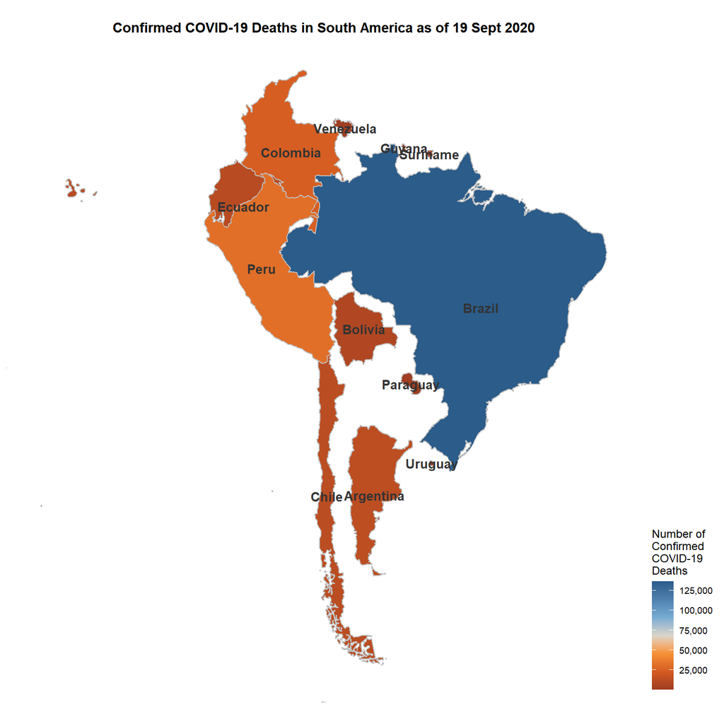

```r
covid_countries3 <- covid_countries[-c(7),]

covid_cart_ncont <- covid_countries3 %>%
  cartogram_ncont("newDeath")

ggplot(covid_cart_ncont, aes(fill = newDeath)) +
 geom_sf(color = "gray") +
 scale_fill_gradient2_tableau(
    name = "Number of\nConfirmed\nCOVID-19\nDeaths",
    breaks = seq(0, 150000, by = 25000),
    labels = formatC(seq(0, 150000, by = 25000),
                     big.mark = ",", format = "f", digits = 0)) +
  ggtitle("Confirmed COVID-19 Deaths in South America as of 19 Sept 2020") +
  geom_sf_label(aes(geometry, label = name), size = 3.5, color = "gray20", fill = NA, label.size =   NA, fontface = "bold") +
  theme_map() +
  theme(axis.title.x = element_text(size = 0), axis.title.y = element_text(size = 0)) +
  theme(plot.title = element_text(face="bold", hjust = 0.5)) +
  theme(legend.position = "right",
        legend.direction="vertical")
```